# Lesson 8 – Base R Graphics

Stats 20 – Section 1 – Vivian Lew

Due 7/16/2020 by 11:59pm PDT

## Introduction

I used basic R graphics and R Markdown to put the graphics into this document, your figures may look slightly different due to differences in operating systems (e.g., Windows, Mac) or hardware (different graphics hardware). Your job is to recreate the graphics you see as best as you are able using R and R Markdown.

We are grading your R code and the overall correctness of the type of graphic and correct representation of the data. Other issues such as graphic size, colors used, line type, font size, or font type are not important. Therefore do not waste time trying to make your submission look **exactly** like these examples, it won’t happen.

In sum, your graphic should convey the same “story” as my graphic, which is mostly about type of graphic (e.g., histogram), legend (if used), titles or captions, and added features like extra lines. The other aspects of a graphic, such as color, the size (I like them big because my eyes are weak), whether lines are solid or dashed etc. are not as vital.

## 1. Line Graph and Multiple Lines with legend

Please recreate this line graph by using the file named ST3Covid19.RData. The data can be found in CCLE Week 3, it was obtained from the New York Times. There are 3 data frames from 3 different states (California, Florida and Texas). The important variables are dailydeaths and the date in each dataset. Titles and a legend help to make the relationship clearer and you should include those for full credit. I used the colors green, violet and cyan, but you can choose your own.

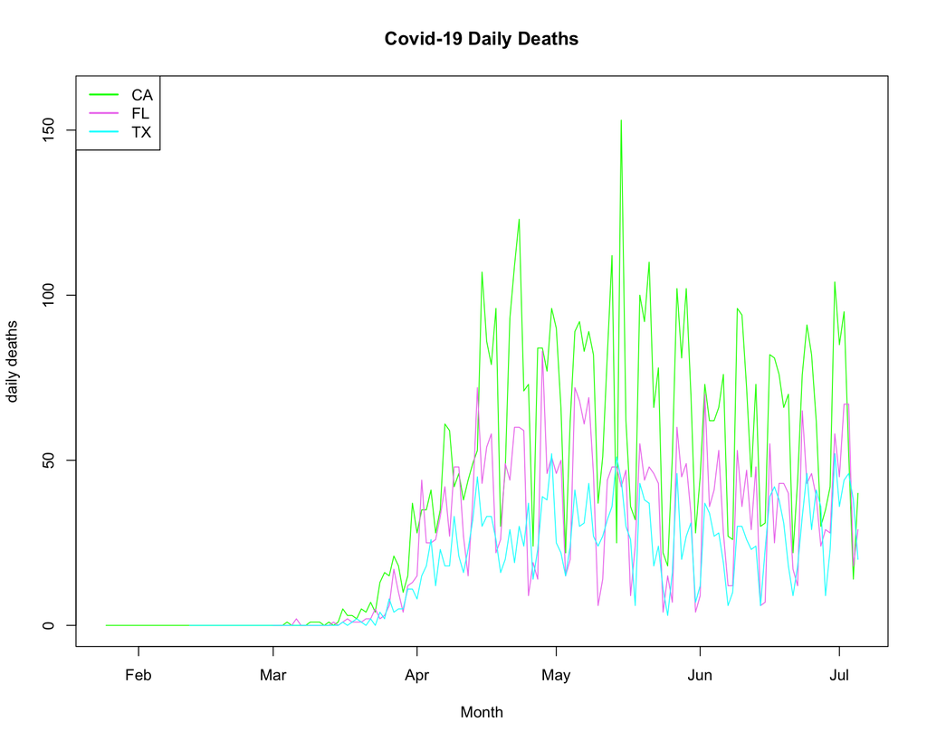

If you want to make this a little more legible (not required), you can add a line like:

```
lines(smooth.spline(CA$dailydeaths ~ CA$date, spar = 0.5),
                    col = "darkgreen", lwd = 2)
```

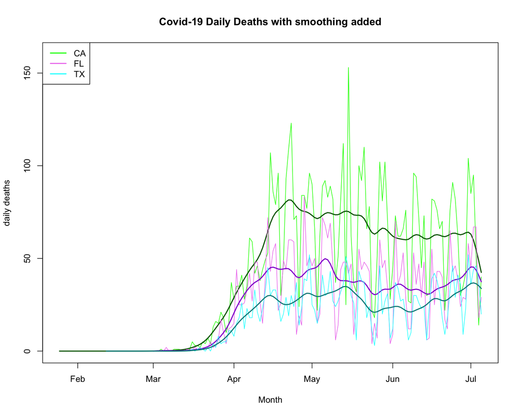

## 2. Boxplots

Please recreate this double boxplot graphic by using the datasets found at:

http://www.stat.ucla.edu/~vlew/datasets/DISNEY.csv

and

http://www.stat.ucla.edu/~vlew/datasets/PAYPAL.csv

which are daily US stock prices categorized by year-month for Disney and Paypal. You should NOT download these, instead, read them directly from the internet in your R code.

The graphic uses the variables Adj Close (adjusted closing stock price) and YM to give us boxplot distributions for each month of the year for the two stock from 7/2019 - 6/2020. If you use the boxplot option “at =” (e.g., at = 1:12 - 0.1 and at = 1:12 + 0.1) you can offset the plotting slightly so the boxes are side by side and not on top of each other. A help(boxplot) or ?boxplot will be useful here. You will need a legend for clarity and titles too.

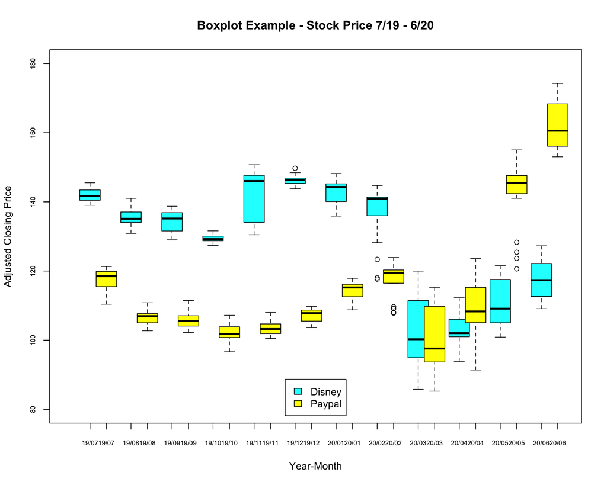

## 3. Histogram

Please demonstrate that you can put three plots on a single graphic using R (not photoshop etc.) by drawing histograms of yelp ratings for Vegan, Buffets and Sports Bars as demonstrated below. Use the dataset http://www.stat.ucla.edu/~vlew/datasets/yelp3.csv and again, try not to read it from your hard drive, but read the data directly from the website into R. The colors used were orange, blue and maroon and those are densities on the y-axis (not frequencies). I adjusted the fig.height in R Markdown so the result would look less “squished”.

[figure not shown]

## 4. Scatter plots

### A. A scatter plot matrix

Please construct a scatter plot matrix using the variables 5,10,18:20 and 23 from the dataset midwest a built-in dataset found in package ggplot2 (we’re using the data only, not the graphing functions) and give it a title.

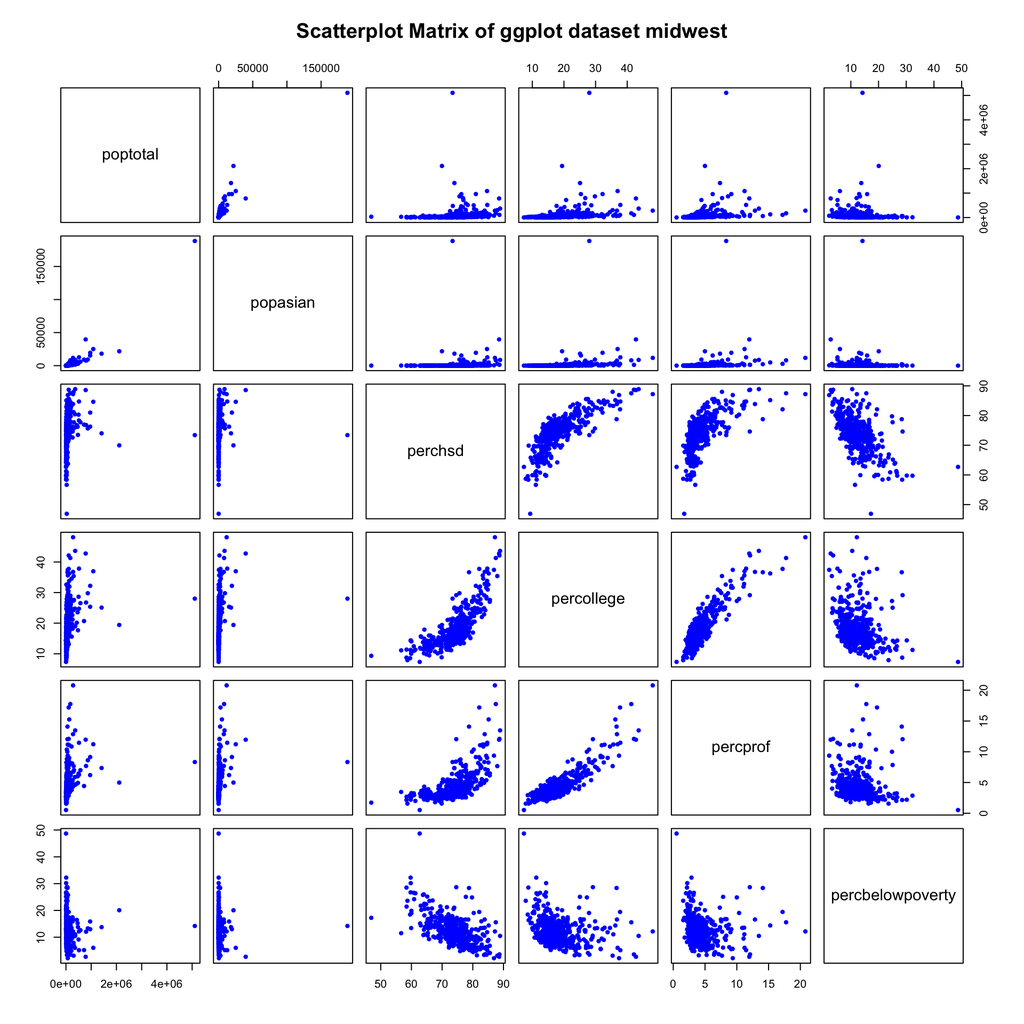

### B. Scatterplot with medians added, colors and legend

Please construct a single scatter plot of perchsd (x) and percollege (y) with points colored by state using *midwest* . Adding the option “col=factor(state)” will allow you to color the points by state (you don’t need the exact colors I used, any set which distinguishes them will do). Add lines representing the median x and the median y values to the graph. Appropriately title and label the graphic.

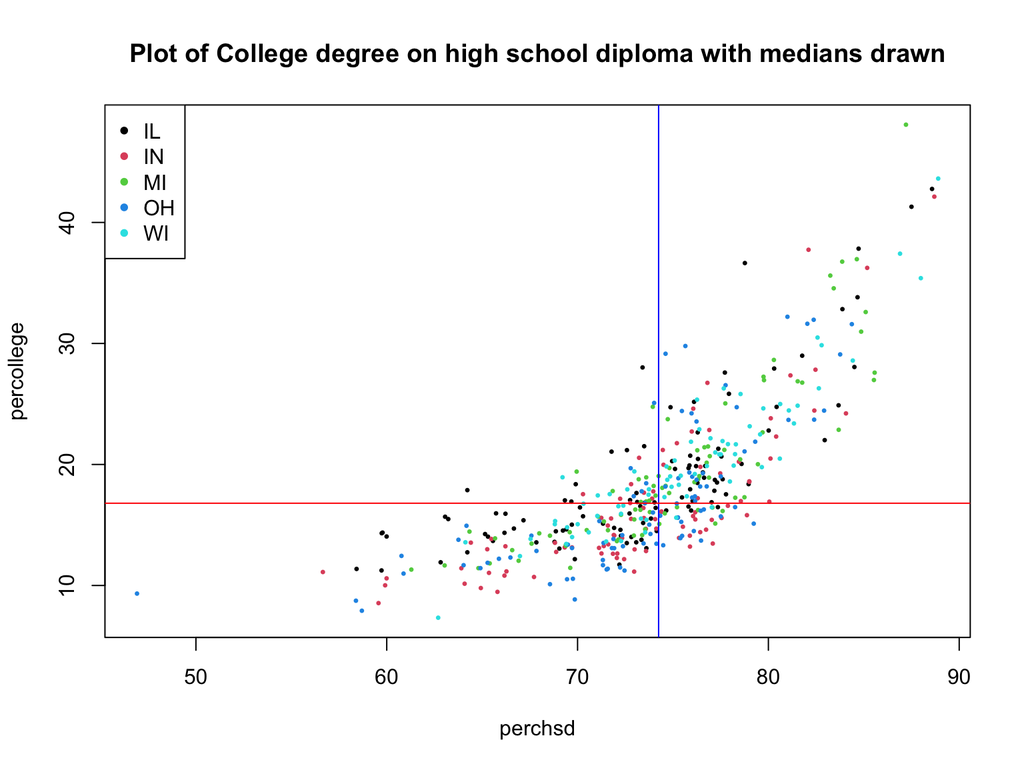

### C. Scatterplot with Regression Line

Using midwest again, please construct a single scatter plot of percollege (x) and percprof (y) and add a linear regression line to it. An easy way to add the regression is to use abline() (it plots straigh lines) and nest a lm() inside of it.

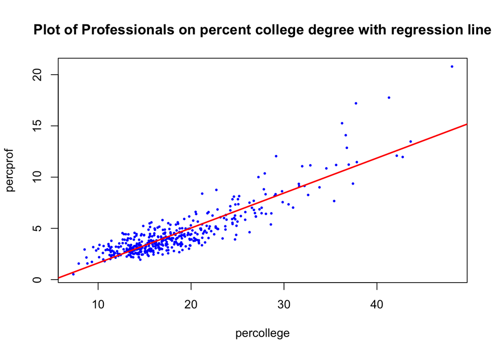

# 5. Barplot

Using the built-in dataset diamonds from ggplot2, please create a set of bar plots. Do remember that barplots need tabled data (most easily crated using the table() function)

## A. Two barplots drawn side by side

The first barplot uses the variable cut and the second uses the variable color.

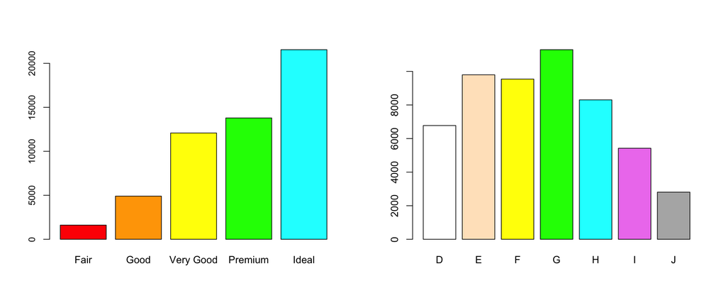

## B. Stacked barplot

This stacked barplot involves using the variable “color” to define the bars (group) and then the distribution of the variable “cut” is shown within each bar. Different colors should be used to make the distribution clear within bar, but the specific choices are unimportant. Stacked barplots almost always involve the use of table() with two-variables where table(var1, var2) has var1 is the distribution with var2 the group.

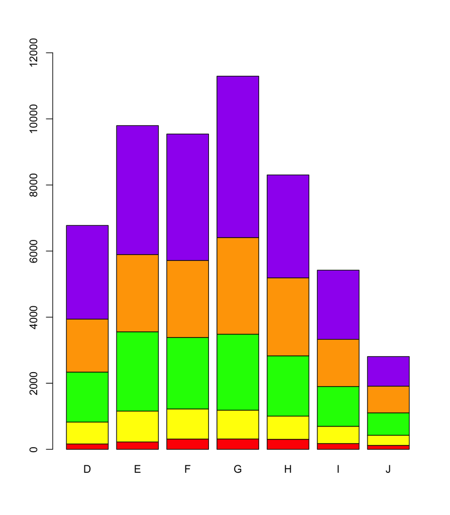

## C. Percent Stacked Barplot

This allows easier comparison across colors. There are several ways to create this, but the easiest may be to use the function prop.table() in addition to table()

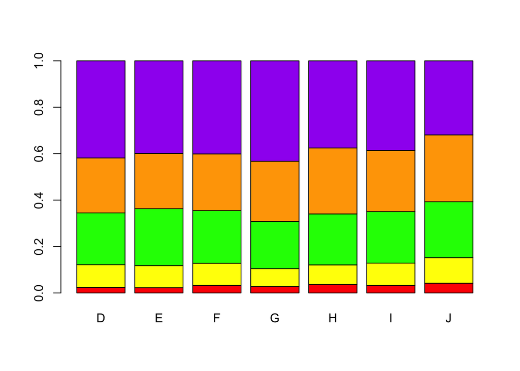

## D. Grouped Barplot

A grouped barplot – here color is the grouping variable (D-J) and within each color group, the distribution of cut is shown. The easiest way to generate these plots is to generate a two-way table of the data and add the option beside= for the barplot.

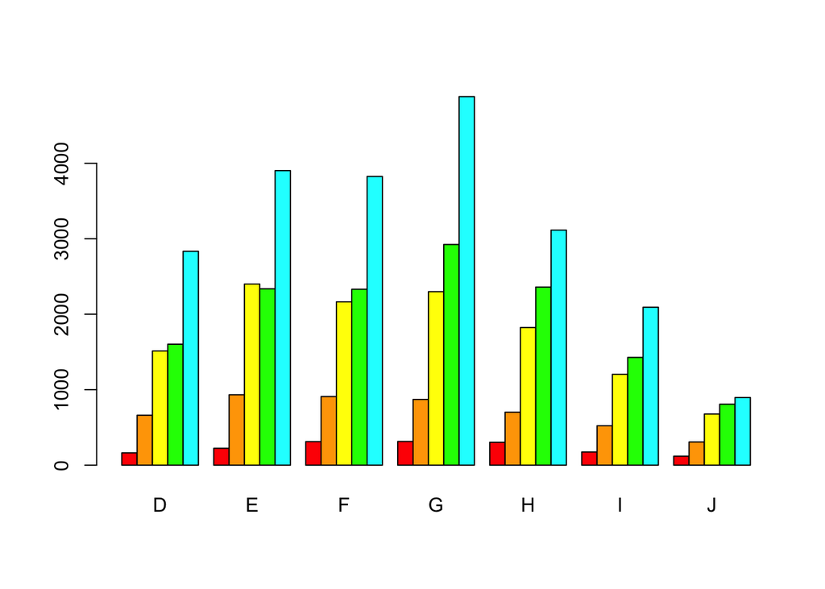

# 6. What to Turn in For Credit

- All of the requested graphics and their associated code. All programmed using Base R (ggplot2 was only used for it’s built-in data, not to graph).
- Name your file Lastname_Firstname_Lesson08.Rmd a model appears in the next link
- Submit a .Rmd file and the .html knitted/rendered result to the appropriate link in Week 3 no later than 7/16/2020 11:59PM PDT.